# How Can a Wellness Technology Company Play It Smart?

Ruoyi Jin

2022-07-19

### 1. Ask Phase

- Business Objectives: -What are some trends in smart device usage? -How could these trends apply to Bellabeat customers? -How could these trends help influence Bellabeat marketing strategy?
- Stakeholders: -Urška Sršen: Bellabeat’s co-founder and Chief Creative Officer -Sando Mur: Mathematician and Bellabeat’s co-founder; key member of the Bellabeat executive team -Bellabeat marketing analytics team: A team of data analysts responsible for collecting, analyzing, and reporting data that helps guide Bellabeat’s marketing strategy.

### 2. Prepare Phase

- Identify: The data is collected by survey between 03.12.2016-05.12.2016 by via Amazon Mechanical Turk.
- ROCCC: Reliable: No. The data was collected by survey, the result is not accurate. Original: No. The data was collected by a third part. Comprehensive: Yes. The data are clear and easy to read. Current: No. The survey was 6 years ago. Cite: No.
- Downloaded and stored to personal hard drive.

### 3. Process Phase:

- Set up my R environment:

  In this progress, I need to Install required packages:
  - tidyverse (for data import and wrangling)
  - lubridate (for date functions)
  - ggplot2 (for visualization)

```r
library("tidyverse")
library("lubridate")
```

```r
library("ggplot2")
```

- Then, let’s create a dataframe named “daily_activity” and “sleep_day” for “dailyActivity_merged.csv” and “sleepDay_merged.csv”.

```r
daily_activity <- read.csv("dailyActivity_merged.csv")
sleep_day <- read.csv("sleepDay_merged.csv")
```

Take a look at the daily_activity and sleep_day.

```r
head(daily_activity)
```

```
##           Id ActivityDate TotalSteps TotalDistance TrackerDistance
## 1 1503960366    4/12/2016      13162          8.50            8.50
## 2 1503960366    4/13/2016      10735          6.97            6.97
## 3 1503960366    4/14/2016      10460          6.74            6.74
## 4 1503960366    4/15/2016       9762          6.28            6.28
## 5 1503960366    4/16/2016      12669          8.16            8.16
## 6 1503960366    4/17/2016       9705          6.48            6.48
##   LoggedActivitiesDistance VeryActiveDistance ModeratelyActiveDistance
## 1                        0               1.88                     0.55
## 2                        0               1.57                     0.69
## 3                        0               2.44                     0.40
## 4                        0               2.14                     1.26
## 5                        0               2.71                     0.41
## 6                        0               3.19                     0.78
##   LightActiveDistance SedentaryActiveDistance VeryActiveMinutes
## 1                6.06                       0                25
## 2                4.71                       0                21
## 3                3.91                       0                30
## 4                2.83                       0                29
## 5                5.04                       0                36
## 6                2.51                       0                38
##   FairlyActiveMinutes LightlyActiveMinutes SedentaryMinutes Calories
## 1                  13                  328              728     1985
## 2                  19                  217              776     1797
## 3                  11                  181             1218     1776
## 4                  34                  209              726     1745
## 5                  10                  221              773     1863
## 6                  20                  164              539     1728
```

```r
head(sleep_day)
```

```
##           Id          SleepDay TotalSleepRecords TotalMinutesAsleep
## 1 1503960366 4/12/2016 0:00:00                 1                327
## 2 1503960366 4/13/2016 0:00:00                 2                384
## 3 1503960366 4/15/2016 0:00:00                 1                412
## 4 1503960366 4/16/2016 0:00:00                 2                340
## 5 1503960366 4/17/2016 0:00:00                 1                700
## 6 1503960366 4/19/2016 0:00:00                 1                304
##   TotalTimeInBed
## 1            346
## 2            407
## 3            442
## 4            367
## 5            712
## 6            320
```

Check how many user we collect in each dataframe.

```r
n_distinct(daily_activity$Id)
```

```
## [1] 33
```

```r
n_distinct(sleep_day$Id)
```

```
## [1] 24
```

And How many observations are there in each dataframe.

```r
nrow(daily_activity)
```

```
## [1] 940
```

```r
nrow(sleep_day)
```

```
## [1] 413
```

check the summary of two dataframe:

```r
print("daily_activity:")
```

```
## [1] "daily_activity:"
```

```r
daily_activity %>%
  select(TotalSteps,
         TotalDistance,
         SedentaryMinutes) %>%
  summary()
```

```
##    TotalSteps    TotalDistance    SedentaryMinutes
##  Min.   :    0   Min.   : 0.000   Min.   :   0.0
##  1st Qu.: 3790   1st Qu.: 2.620   1st Qu.: 729.8
##  Median : 7406   Median : 5.245   Median :1057.5
##  Mean   : 7638   Mean   : 5.490   Mean   : 991.2
##  3rd Qu.:10727   3rd Qu.: 7.713   3rd Qu.:1229.5
##  Max.   :36019   Max.   :28.030   Max.   :1440.0
```

```r
print("sleep_day:")
```

```
## [1] "sleep_day:"
```

```r
sleep_day %>%
  select(TotalSleepRecords,
         TotalMinutesAsleep,
         TotalTimeInBed) %>%
  summary()
```

```
##  TotalSleepRecords TotalMinutesAsleep TotalTimeInBed
##  Min.   :1.000     Min.   : 58.0      Min.   : 61.0
##  1st Qu.:1.000     1st Qu.:361.0      1st Qu.:403.0
##  Median :1.000     Median :433.0      Median :463.0
##  Mean   :1.119     Mean   :419.5      Mean   :458.6
##  3rd Qu.:1.000     3rd Qu.:490.0      3rd Qu.:526.0
##  Max.   :3.000     Max.   :796.0      Max.   :961.0
```

We can Plot a few explorations, but first let’s check the structure:

```r
str(daily_activity)
```

```
## 'data.frame':    940 obs. of  15 variables:
##  $ Id                      : num  1.5e+09 1.5e+09 1.5e+09 1.5e+09 1.5e+09 ...
##  $ ActivityDate            : chr  "4/12/2016" "4/13/2016" "4/14/2016" "4/15/2016" ...
##  $ TotalSteps              : int  13162 10735 10460 9762 12669 9705 13019 15506 10544 9819 ...
##  $ TotalDistance           : num  8.5 6.97 6.74 6.28 8.16 ...
##  $ TrackerDistance         : num  8.5 6.97 6.74 6.28 8.16 ...
##  $ LoggedActivitiesDistance: num  0 0 0 0 0 0 0 0 0 0 ...
##  $ VeryActiveDistance      : num  1.88 1.57 2.44 2.14 2.71 ...
##  $ ModeratelyActiveDistance: num  0.55 0.69 0.4 1.26 0.41 ...
##  $ LightActiveDistance     : num  6.06 4.71 3.91 2.83 5.04 ...
##  $ SedentaryActiveDistance : num  0 0 0 0 0 0 0 0 0 0 ...
##  $ VeryActiveMinutes       : int  25 21 30 29 36 38 42 50 28 19 ...
##  $ FairlyActiveMinutes     : int  13 19 11 34 10 20 16 31 12 8 ...
##  $ LightlyActiveMinutes    : int  328 217 181 209 221 164 233 264 205 211 ...
##  $ SedentaryMinutes        : int  728 776 1218 726 773 539 1149 775 818 838 ...
##  $ Calories                : int  1985 1797 1776 1745 1863 1728 1921 2035 1786 1775 ...
```

```r
str(sleep_day)
```

```
## 'data.frame':    413 obs. of  5 variables:
##  $ Id                : num  1.5e+09 1.5e+09 1.5e+09 1.5e+09 1.5e+09 ...
##  $ SleepDay          : chr  "4/12/2016 0:00:00" "4/13/2016 0:00:00" "4/15/2016 0:00:00" "4/16/2016 0:00:00" ...
##  $ TotalSleepRecords : int  1 2 1 2 1 1 1 1 1 1 ...
##  $ TotalMinutesAsleep: int  327 384 412 340 700 304 360 325 361 430 ...
##  $ TotalTimeInBed    : int  346 407 442 367 712 320 377 364 384 449 ...
```

We find the Id in daily_activity and sleep_day are numeric, we need to both Id to character.

```r
daily_activity <-  mutate(daily_activity, Id = as.character(Id))
sleep_day <-  mutate(sleep_day, Id = as.character(Id))
```

Then, we can plot both frame.

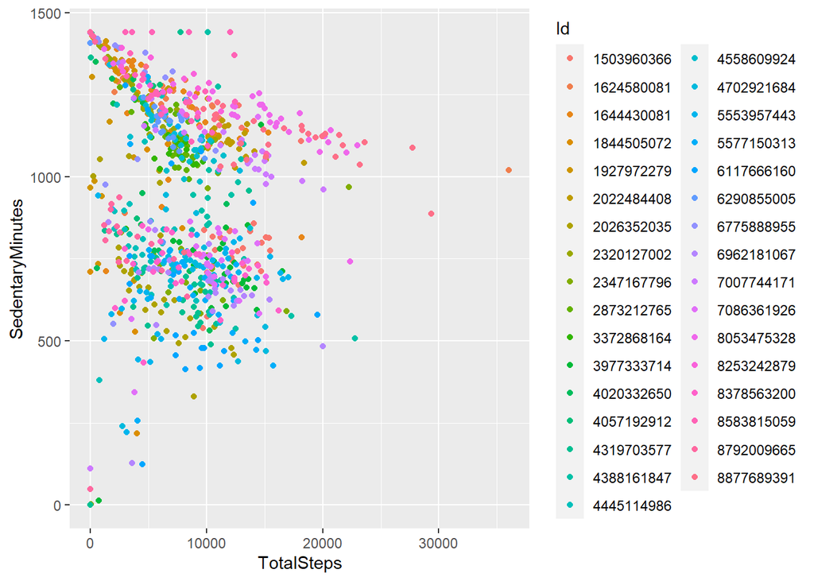

```r
ggplot(daily_activity)+
  geom_point(mapping = aes(x=TotalSteps, y=SedentaryMinutes,color=Id))
```

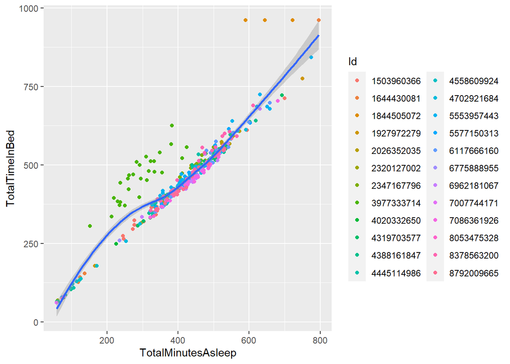

```r
ggplot(sleep_day)+
  geom_point(mapping = aes(x=TotalMinutesAsleep, y=TotalTimeInBed,color=Id))+
  geom_smooth(mapping = aes(x=TotalMinutesAsleep, y=TotalTimeInBed))
```

Compare column names each of the files:

```r
colnames(daily_activity)
```

```
##  [1] "Id"                       "ActivityDate"
##  [3] "TotalSteps"               "TotalDistance"
##  [5] "TrackerDistance"          "LoggedActivitiesDistance"
##  [7] "VeryActiveDistance"       "ModeratelyActiveDistance"
##  [9] "LightActiveDistance"      "SedentaryActiveDistance"
## [11] "VeryActiveMinutes"        "FairlyActiveMinutes"
## [13] "LightlyActiveMinutes"     "SedentaryMinutes"
## [15] "Calories"
```

```r
colnames(sleep_day)
```

```
## [1] "Id"                 "SleepDay"           "TotalSleepRecords"
## [4] "TotalMinutesAsleep" "TotalTimeInBed"
```

- Note that both datasets have the ‘Id’ field - this can be used to merge the datasets.* Here, by “Id” we can apply:

```r
combined_data <- merge(sleep_day, daily_activity, by="Id")
```

Take a look at how many participants are in this data set.

```r
n_distinct(combined_data$Id)
```

```
## [1] 24
```

Check the structure and convert the Id to character:

```r
str(combined_data)
```

```
## 'data.frame':    12441 obs. of  19 variables:
##  $ Id                      : chr  "1503960366" "1503960366" "1503960366" "1503960366" ...
##  $ SleepDay                : chr  "4/12/2016 0:00:00" "4/12/2016 0:00:00" "4/12/2016 0:00:00" "4/12/2016 0:00:00" ...
##  $ TotalSleepRecords       : int  1 1 1 1 1 1 1 1 1 1 ...
##  $ TotalMinutesAsleep      : int  327 327 327 327 327 327 327 327 327 327 ...
##  $ TotalTimeInBed          : int  346 346 346 346 346 346 346 346 346 346 ...
##  $ ActivityDate            : chr  "5/7/2016" "5/6/2016" "5/1/2016" "4/30/2016" ...
##  $ TotalSteps              : int  11992 12159 10602 14673 13162 10735 15355 14070 13154 11181 ...
##  $ TotalDistance           : num  7.71 8.03 6.81 9.25 8.5 ...
##  $ TrackerDistance         : num  7.71 8.03 6.81 9.25 8.5 ...
##  $ LoggedActivitiesDistance: num  0 0 0 0 0 0 0 0 0 0 ...
##  $ VeryActiveDistance      : num  2.46 1.97 2.29 3.56 1.88 ...
##  $ ModeratelyActiveDistance: num  2.12 0.25 1.6 1.42 0.55 ...
##  $ LightActiveDistance     : num  3.13 5.81 2.92 4.27 6.06 ...
##  $ SedentaryActiveDistance : num  0 0 0 0 0 0 0 0 0 0 ...
##  $ VeryActiveMinutes       : int  37 24 33 52 25 21 73 45 48 16 ...
##  $ FairlyActiveMinutes     : int  46 6 35 34 13 19 14 24 28 12 ...
##  $ LightlyActiveMinutes    : int  175 289 246 217 328 217 216 250 189 243 ...
##  $ SedentaryMinutes        : int  833 754 730 712 728 776 814 857 782 815 ...
##  $ Calories                : int  1821 1896 1820 1947 1985 1797 2013 1959 1898 1837 ...
```

### 4. Analysis Phase

- Check the total number of users: Then we can use the BigQuery to analysis the data. Here we can apply:

SELECT  
COUNT(*) AS TOTAL_DATA  
FROM  
`task2-356801.FitBit.combined_data`

We have total 12441 rows.

SELECT  
COUNT(DISTINCT(Id)) AS num_of_user  
FROM  
`task2-356801.FitBit.combined_data`

We have totally 24 users’s data.

- Check how many day per user report:

SELECT  
Id,  
COUNT(DISTINCT(ActivityDate)) AS TOTAL_REPORT_DAY FROM  
`task2-356801.FitBit.combined_data`  
GROUP BY  
Id  
ORDER BY  
TOTAL_REPORT_DAY DESC

We have 16 users upload the data 31 days, one user upload 18 days.

- Want to know the average of report date: